# Índice de pobreza mundial

Kenneth Roy Cabrera Torres

Miércoles, 6 de febrero de 2019

En el sitio del [Banco Mundial](https://datos.bancomundial.org/tema/pobreza) se encuentra la base de datos con el indicador de probreza nombrado como: “Brecha de pobreza a $1,90 por día (2011 PPA) (%)”.

PPA: Paridad del Poder Adqusitivo o PPP en inglés Purchasing Power Parity.

Responda las siguientes preguntas:

- 1. (10%). Utilizando esta base de datos de las [codificaciones de los países](https://labscn-unalmed.github.io/modulo-R/slides/03_Arreglo_Base_Datos.html), ¿Están todos los códigos ISO3 de la base de países en la base de datos del Banco Mundial? ¿Cuáles no estan?
- 2. (10%). Utilizando esta base de datos de las [codificaciones de los países](https://labscn-unalmed.github.io/modulo-R/slides/03_Arreglo_Base_Datos.html), ¿Están todos los códigos ISO3 del Banco Mundial en la base de datos de países? ¿Cuáles no están?
- 3. (80%). Realice por cada “**Region**” una gráfica que muestre los datos de los indices de probreza de los diez países de cada región con promedio de pobreza más bajos. Trabaje sólo con los paises que tengan dos o más valores del índice registrados en el periodo de tiempo desde 1960 a 2018.

Por ejemplo, para la región de América Latina y el Caribe la gráfica sería la siguiente:

Se entregará el código y las respuestas a las preguntas el día miércoles 6 de febrero de 2018 antes de las 23:59 hora de Colombia al correo *krcabrer@unal.edu.co*, en asunto escribir **[ModuloR]**.

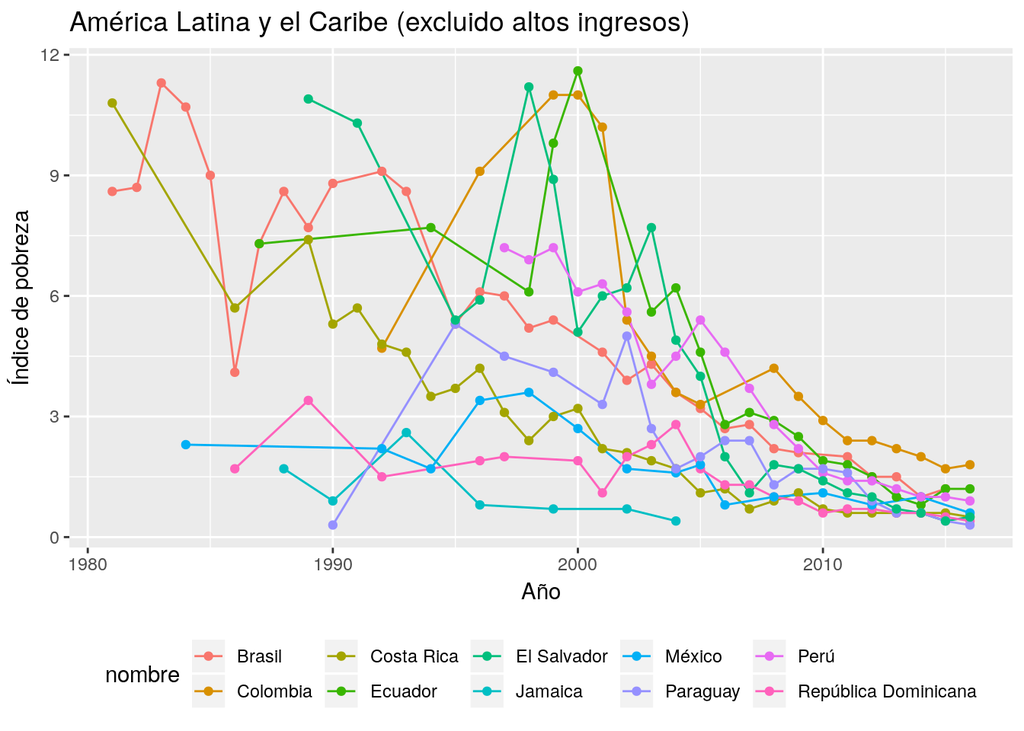